# Out-of-sight, Out-of-mind? Distance Decay in Use and Non-use Value of Water Quality

## UGA Applied Micro Workshop

### Emmett Reynier and Xibo Wan

### October 23rd, 2026

# Water quality (under)valuation

The US has spent over $5 trillion to clean water pollution<sup>◊</sup>

[figure not shown]

.footnote[◊ [Keiser and Shapiro (JEP 2019)](https://doi.org/10.1257/jep.33.4.51)]

# Water quality (under)valuation

However, 67% of surface water 20% of drinking water regulations fail a benefit-cost test,<sup>◊</sup>

compared to just 8% for air regulations.

[figure not shown]

.footnote[◊ [Keiser and Shapiro (JEP 2019)](https://doi.org/10.1257/jep.33.4.51)]

# Water quality (under)valuation

Why are benefit-cost ratios for water regulations so low?

**Among other reasons discussed** in [Keiser and Shapiro (JEP 2019)](https://doi.org/10.1257/jep.33.4.51): lack of quantified health effects, few market-based regulations, lots of substitutability for water quality, and difficulty estimating non-use values.

> Many studies focus on recreation, amenity, or other types of “use” values that people derive from visiting surface waters. Other “nonuse” or “existence” values for clean water may also be important, though they are difficult to measure well.

# Water quality (under)valuation

The US EPA relies on a metaanalysis-based benefit transfer function to estimate the benefits of water quality improvements ([Corona et al. 2020](https://doi.org/10.3368/wple.96.4.478)).

# Water quality (under)valuation

The US EPA relies on a metaanalysis.bold[-based ].bold[benefit transfer ].bold[function] to estimate the benefits of water quality improvements ([Corona et al. 2020](https://doi.org/10.3368/wple.96.4.478)).

1. Metaanalysis: Collect dataset of stated preference studies (N = ~200) valuing changes in water quality, run a regression of WTP on that change and covariates describing study region and methods.
`$$WTP_s = \beta \Delta WQ_s + f(X^{region}_s) + g(X^{methods}_s) + \varepsilon_s$$`

# Water quality (under)valuation

The US EPA relies on a metaanalysis.bold[-based ].hi-blue[benefit transfer ].bold[function] to estimate the benefits of water quality improvements ([Corona et al. 2020](https://doi.org/10.3368/wple.96.4.478)).

1. Metaanalysis: Collect dataset of stated preference studies (N = ~200) valuing changes in water quality, run a regression of WTP on that change and covariates describing study region and methods.
`$$WTP_s = \beta \Delta WQ_s + f(X^{region}_s) + g(X^{methods}_s) + \varepsilon_s$$`

2. Benefit Transfer: Make prediction from estimated function for proposed change `\(\Delta WQ_j\)` you want to value, `\(\widehat{WTP}_j = \hat{\beta} \Delta WQ_j + \hat{f}(X^{region}_j)\)`

# Water quality (under)valuation

The US EPA relies on a metaanalysis-based benefit transfer function to estimate the benefits of water quality improvements ([Corona et al. 2020](https://doi.org/10.3368/wple.96.4.478)).

- Very difficult to incorporate a distance effect on WTP in the metaregression since it relies on aggregated data
- Limit extent of market to 100 miles based on 1996 National Survey on Recreation, where about 80% of all recreational uses were within 100mi ([Viscusi et al. 2008](https://doi.org/10.1007/s10640-007-9186-4))
- Perceived to be a **"conservative assumption"** that leaves considerable benefits on the table
- Benefits are very sensitive to the **"analyst's choice"** for extent of market

### More generally...

- **Revealed preference methods** inform us about the decay of use values
- We know **considerably less** about how distance affects non-use values

# Our approach

**Q** What is the relationship between distance and WTP for water quality? Does this lead to significant under-estimation of water quality benefits?

- Nest a travel cost random utility model within a utility function that is also directly affected by water quality, which can vary by distance

- Estimate travel cost RUM with cell phone-based mobility data on trips to water-based recreation sites

- Combine with several existing stated preference studies to estimate rest of utility parameters

### Results Preview

- Both use and non-use values **decline with distance**, but remain economically meaningful well beyond 100 miles
- A 100-mile extent-of-market captures only **about half** of total WTP for the Steam Electric rule's water quality changes

# Cell phone mobility data

# Cell phone mobility data

### Patterns data from Advan

- Count of monthly visits from an origin CBG to a destination POI
- Follow [Wan et al (2024)](https://www.doi.org/10.1088/1748-9326/ad801c) in selecting 69K water-based recreation sites by intersecting Advan park POIs with NHDv2 .smallest[[[details]](#app-cell-data-poi)]

[figure not shown]

# Cell phone mobility data

### Patterns data from Advan

- Count of monthly visits from an origin CBG to a destination POI
- Follow [Wan et al (2024)](https://www.doi.org/10.1088/1748-9326/ad801c) in selecting 69K water-based recreation sites by intersecting Advan park POIs with NHDv2 .smallest[[[details]](#app-cell-data-poi)]
- Calculate driving distances from each CBG to POI using OSRM .smallest[[[details]](#app-osrm)]
- Aggregate sites to HUC12 level and CBGs to zipcode level

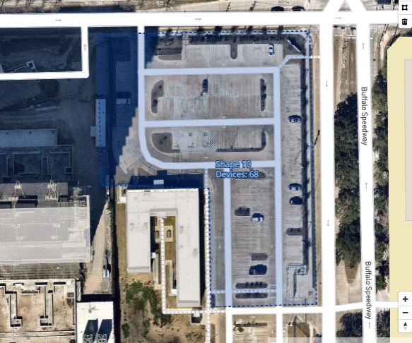

Polygon

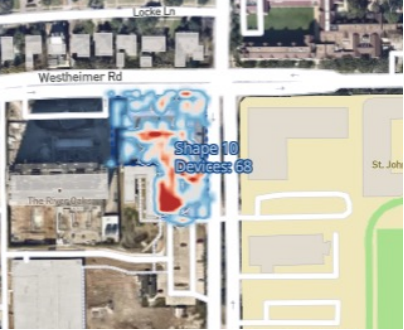

Visits

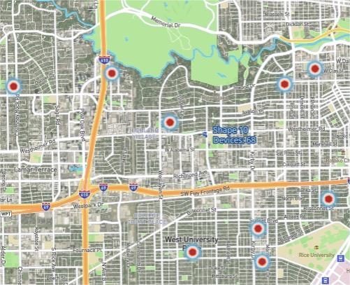

Home

# Reduced Form

# Reduced form model with cell data

We begin with some simple regressions measuring distance decay in visitation with the cell-phone data:

`$$\log{\text{Visit}_{ijt}} = f(d_{ij}) + \text{zip}_i + \text{huc}_j + \text{ym}_t + \varepsilon_{ijt}$$`

where
- `\(\text{Visit}_{ijt}\)` are monthly visits (normalized by number of devices in origin)
- `\(d_{ij}\)` is driving distance from zip code `\(i\)` to a HUC12 `\(j\)`
- `\(\text{zip}_i\)` and `\(\text{huc}_j\)` are origin and destination fixed effects
- `\(\text{ym}_t\)` are year-month fixed effects

We test different functional forms for effect of distance on visits, `\(f(\cdot)\)`

# Reduced form results

.footnote[[[heterogeneity]](#reduced-form-het)]

[figure not shown]

`\(\implies\)` Steep decay in visits, but still remain beyond 100 miles

# Reduced form results

Distance decay slower for **western water sites with fewer substitutes**

[figure not shown]

# Structural decomposition of use and non-use values

# Structural Model Details

[Day et al. (2019)](https://doi.org/10.1016/j.jeem.2019.102256) and [Kim and Lupi (2023)](https://doi.org/10.1017/age.2023.26) propose a method for combining stated and revealed preferences to decompose use and non-use values.
- Our goal is to take this model to survey data from **several studies**
- Fill in missing visitation data with cell phone-based mobility data

Person `\(i\)`'s utility conditional on visiting water feature `\(j\)` in month `\(t\)` and state of the world `\(s\)` is

`$$u_{ijts} = \color{#57754D}{v_{ijts}^{\text{use}}} + \color{#4682B4}{v_{its}^{\text{nonuse}}} + v_{ijts}^{o} + \varepsilon_{ijts}$$`

Numeraire is linear in income net of travel cost `\(TC_{ij}\)` and program cost `\(c_s\)`<sup>†</sup>

`$$v_{ijts}^o = \gamma(y_{it} - TC_{ij} - c_s)$$`

† The baseline case has \(c_0 = 0\).

# Structural Model Details

Use Value If person `\(i\)` decides to visit site `\(j\)`, the utility they get is a site-time specific constant `\(\alpha_{jt}\)` plus a vector representing site quality `\(q_{js}\)`

`$$\color{#57754D}{v_{ijts}^{\text{use}}} = \alpha_{jt} + q_{js}^\prime \beta$$`

Thus, `\(\beta\)` reflects the marginal use utility of quality.

Non-use Value is a distance-weighted sum of quality across all sites,

`$$\color{#4682B4}{v_{is}^\text{nonuse}} = b \sum_{j} \omega(d_{ij}; \lambda)\, q_{js}$$`

where `\(w(\cdot)\)` is a function of the distance `\(d_{ij}\)` with shape `\(\lambda\)` and `\(b\)` is the marginal non-use utility of quality. **Does not depend on actual site choice!**

People visit the sites with the highest indirect utility. They then vote on the proposed policy from the sum of their **expected use and non-use utility**. .smallest[[[WTP functions]](#wtp-functions)]

# Stated Preference Data

We are greatful to the authors of three studies who have shared microdata from their studies with us: [Johnston et al. (2023)](https://doi.org/10.1073/pnas.2120255119), [Vossler et al. (2023)](https://doi.org/10.1073/pnas.2120251119), and [Moore et al. (2026)](https://www.epa.gov/environmental-economics/valuing-changes-aquatic-biodiversity-and-recreation-nationwide-survey).

### [Moore et al. (2026)](https://www.epa.gov/environmental-economics/valuing-changes-aquatic-biodiversity-and-recreation-nationwide-survey)

- **National** study, covering continental US
- Values improvements in WQI and biodiversity measure (O/E)
  - Vary the spatial scale of improvements
  - Vary whether improvement is local or non-local
- Base data is at **HUC2** level
- Gives us **34,032 responses** (5,686 respondents, up to 6 choice questions each) for study area of **>90,000 HUC12s**

[figure not shown]

### [Johnston et al. (2023)](https://doi.org/10.1073/pnas.2120255119)

- Focused on New England
- Survey instrument compares BAU to alternative policy scenarios in 2025
- Model three different water quality metrics using FRAMES
  - Aggregate **river segments** to HUC12 with length-weighted average
  - We use their overall WQI, which combines chlorides, fecal coliforms, and dissolved inorganic nitrogen
- Gives us **1,239 responses** for study area of **1,836 HUC12s**

[figure not shown]

### [Vossler et al. (2023)](https://doi.org/10.1073/pnas.2120251119)

- Focused on the upper-midwest
- Values improvements in the **Biological Condition Gradient (BCG)**
  - Vary the spatial scale of improvements (HUC4, 3 HUC4s, region)
  - Vary whether improvement is local or non-local
- Base data is at **HUC8** level
- Gives us **17,653 responses** for study area of **11,747 HUC12s**

[figure not shown]

# Estimation

# Estimation

We estimate the model in three steps:

1. Estimate a state-of-the-art travel cost RUM using cell data: the price coefficient `\(\hat\gamma^{cell}\)` and site-month constants `\(\hat\delta_{jt}\)` .smallest[[[details]](#app-tc-rum)]

- Using cell data allows us to estimate **high-dimensional fixed effects**
  - Would be very difficult with survey data (small sample size, recall)

1. Decompose the site-month constants on satellite Secchi depth, with an IV, to get the marginal use value of water clarity `\(\hat\beta\)` .smallest[[[details]](#use-value-clarity)]

1. Hold `\(\hat\gamma^{cell}\)`, `\(\hat\delta_{jt}\)`, `\(\hat\beta\)` fixed and estimate the rest, `\(\Theta = \{\gamma^{s}, \phi, b, \lambda\}\)`, from the stated preference votes by maximum likelihood .smallest[[[details]](#app-sp-est)]
  - `\(\phi\)` lets survey respondents weigh the imported use value differently from the cell data (relative scale)

.smallest[[[Parameter Estimates]](#app-parameter-estimates)]

# Use value of water clarity

The first stage gives a constant `\(\hat\delta_{jt}\)` for every site and month, in utility units

We decompose it into the part due to water clarity,

`$$\hat\delta_{jt} = \beta\, \text{Secchi}_{jt} + \xi_{jt}$$`

- `\(\text{Secchi}_{jt}\)`: Secchi depth (m) from satellite imagery
- `\(\xi_{jt}\)` may be correlated with clarity, so we instrument Secchi depth with **land use × precipitation**, which lowers clarity through runoff .smallest[[[instruments]](#app-iv-sets)]

Dividing by the travel cost coefficient gives `\(\hat\beta\)` in **dollars per meter of Secchi per trip**. Survey water quality changes are mapped onto Secchi depth to value their use component .smallest[[[conversions]](#app-wqi-secchi) [[estimates]](#app-parameter-estimates)]

.footnote[[[return]](#est-main)]

# Model fit vs. the original studies

Our WTP vs. each paper's result, on the scenarios shown to respondents

| Study | Decay form | Our WTP | Paper's model | Ratio | Use share | Non-use share |
| --- | --- | --- | --- | --- | --- | --- |
| Johnston et al. | Flat | $797.55 | $664.08 | 1.20 | 27% | 73% |
| Vossler et al. | Gaussian | $202.13 | $236.21 | 0.86 | 59% | 41% |
| Moore et al. | Power | $131.22 | $178.66 | 0.73 | 28% | 72% |

.smallest[Each vote is evaluated at the scenario it was shown. Paper's model: its mean coefficients × each vote's own regressors, including its constant (ASC). Moore et al.: correlated mixed logit. [[Parameter Estimates]](#app-parameter-estimates)]

# Robustness across specifications

Moore et al.: total WTP and its use / non-use split for every specification within 10 AIC of the selected one

[figure not shown]

.footnote[WTP on the votes as cast. Varies the instrument set, the Secchi gap-fill variant, and the non-use decay form; use and non-use are identified in every one. [[instruments]](#app-iv-sets)]

# Results

# MWTP for 1pt WQ in a watershed

For each study we...
1. Consider a 1pt WQ improvement in a single watershed
2. Calculate use and non-use WTP for each respondent .smallest[[[WTP functions]](#wtp-functions)]
3. Repeat 100x for randomly chosen watersheds in study area
4. Take average by distance bin between respondent and watershed

# WTP for 1pt WQ, by distance

[figure not shown]

.footnote[Moore et al. (2026) survey. [[all three studies]](#marginal-wtp-jvn) [[maps]](#app-wtp-maps)]

# Steam Electric

# Steam Electric overview

EPA finalized the **Steam Electric** rule in 2024, placing limits on wastewater from coal-powered electric generating plants. The rule sets zero-discharge standard for...

- Scrubber wastewater from sulfur controls
  - Water used to clean ash from the boilers
  - Leachate associated with coal combustion residual

Estimate social costs of $536 million and benefits of $3.2 billion per year.

- Almost all benefits come from reductions in air pollutants --- half from global GHG, rest from local NOx, SO2, PM health effects
   - **$1.27 million WTP** for use and non-use value of water quality changes

# Steam Electric water quality changes

[figure not shown]

.footnote[[[baseline wqi]](#steam-electric-wq-base)]

# Steam Electric simulation

We use our estimated model to evaluate radius-based extent-of-market assumptions in the context of the  `\(\Delta WQ\)` generated by Steam Electric.

1. Set the extent-of-market radius `\(r\)`
   2. Calculate individual WTP, setting `\(\Delta q_j = 0\)` if `\(dist_{ij} > r\)`
   3. Sum across all individuals in our nationally-representative sample
   4. Repeat for values of `\(r\)` between 50 and 3000

# Steam Electric simulation results

A 100-mile radius captures only **53% of total WTP** (21% of use, 71% of non-use)

[figure not shown]

# Conclusions

### Implications for benefits estimation

- Both use and non-use values **decline with distance**, but remain economically meaningful well beyond 100 miles
- Limiting the extent-of-market to 100 miles misses **about half** of WTP for the Steam Electric rule

### Next Steps

- Reconcile our Moore et al. estimates with the original study's model
- Evaluate other recent EPA Clean Water Act regulations as we did for Steam Electric

# Thank you!

# Appendix

# Cell phone mobility data

### Identifying Water POIs

We intersect the Advan parks polygon with the NHDv2:
- Create 50 meter buffer around park polygons
- Create 20 meter buffer around river flowlines
- Identify lake-based sites as those adjacent to a water body

#### A few important caveats

1. Difficult to identify river visits (esp. river sites across states)
3. Represents approximately 10% of all smartphones
4. Tends to represent a younger demographic than the general population
5. Privacy protection algorithm may lead to biases in estimation .smallest[[[details]](#app-cell-data-privacy)]
6. Mobile GPS positioning may have ~5 meter errors

.footnote[[[return]](#main-cell-data)]

# Advan privacy protection measures

Advan implements the following procedure to protect user's privacy:
1. Differential privacy: add a Laplane noise with `\(N(0,10/9)\)`
1. Discretization: round the number to integer
1. Integer Floor: present a visitor count if `\(floor(V_{ijt})\)` is larger than `\(2\)`
2. Censoring: `\(\max\{4, \text{floor}(V_{ijt})\}\)`

[Connolly, Steinbach, Vo, and Wan (2025)](https://www.dropbox.com/scl/fi/p1pmfzod67lcq9c788ki1/CapeCod_Wan.pdf?rlkey=snf54f1jgg2db93n3o3p4jf20&e=1&st=hxn1gj2a&dl=0) that these techniques may lead to bias using standard estimation techniques.

.footnote[[[return]](#app-cell-data-poi)]

# Driving Distances with OSRM

We use the [Open Source Routing Machine (OSRM)](https://project-osrm.org/) to calculate the shortest driving distance between CBG and water-based POI site centroids.
- Getting OSRM to run nationally requires ~100gb of RAM in inital setup (used virtual machine on Google Compute Engine)
- Fed it 60 million lat/lon pairs and waited for 3 days...

[figure not shown]

.footnote[[[return]](#main-cell-data)]

# Reduced form heterogeneity

.bold[Rivers]

[figure not shown]

.bold[Lakes]

[figure not shown]

.footnote[[[return]](#reduced-form-results)]

# Structural Model Details

### Welfare measures

We can calculate WTP for a given water quality change `\(\Delta q\)` as

`\begin{align*}
&\color{#57754D}{WTP^\text{use}_i} = \frac{\phi}{\hat\gamma^{cell}}\sum_t\log{\left[\frac{\sum_j \exp{\left(\hat{\delta}_{jt} + \hat\beta\, \Delta q_j - \hat\gamma^{cell} TC_{ij}\right)}}{\sum_j \exp{\left(\hat{\delta}_{jt} - \hat\gamma^{cell} TC_{ij}\right)}}\right]} \\
&\color{#4682B4}{WTP^\text{nonuse}_i} = \frac{b}{\gamma^{s}}\sum_j \omega_{ij}(\lambda)\, \Delta q_j
\end{align*}`

both of which vary as respondents get further from a given water feature.<sup>†</sup>

† Travel costs \(TC_{ij}\) are a non-linear function of driving distance. .smallest[[[return to model]](#details-2) [[return to results]](#sim-expl)]

# Model Details: Revealed Preferences

Assume that trips occur in the baseline period, `\(s=0\)` before quality change. Then the probability `\(i\)` visits `\(j\)` is

`\begin{align}
  Pr^{visit}_{ijt0} &= Pr(u_{ijt0} - u_{ikt0} > 0)  \quad \forall \; k \neq j \\
  &= Pr\left[(v_{ijt0}^{\text{use}} + v_{it0}^{\text{nonuse}} + v_{ijt0}^{o}) - (v_{ikt0}^{\text{use}} + v_{it0}^{\text{nonuse}} + v_{ikt0}^{o}) > \varepsilon_{ikt0} - \varepsilon_{ijt0}\right] \\
  &= Pr\left[(v_{ijt0}^{\text{use}} + v_{ijt0}^{o}) - (v_{ikt0}^{\text{use}} + v_{ikt0}^{o}) > \varepsilon_{ikt0} - \varepsilon_{ijt0}\right] \quad \forall \; k \neq j
\end{align}`

The non-use values cancel out since they do not depend on choice `\(j\)`. Given T1EV errors, we have

`$$Pr^{visit}_{ijts} = \frac{\exp{\left(\alpha_{jt} + q_{js}^\prime\beta - \gamma (y_{it} - TC_{ij} - c_s)\right)}}{\sum_{k}\exp{\left(\alpha_{kt} + q_{ks}^\prime\beta - \gamma (y_{it} - p_{ik} - c_s)\right)}}$$`

.footnote[[[return]](#est-main)]

# Model Details: Stated Preferences

### Stated preference portion

The utility `\(i\)` receives from state of the world `\(s\)` is

`$$u_{is} = \tilde{v}_{is} + \tilde{\varepsilon}_{is} = T\tilde{v}_{is} + \sum_t\tilde{\varepsilon}_{its}$$`

where `\(\tilde{v}_{is}\)` is the deterministic portion of utility,

`$$\tilde{v}_{is} = \frac{1}{\sigma^{SP}} \left(v^\text{nonuse}_{is} +  \sum_j \exp{\left(v^\text{use}_{ijs} + v^o_{ijs}\right)}\right) + \kappa$$`

`\(\sigma^{SP}\)` is the variance of T1EV shock and the left terms are expected use-utility in state `\(s\)` with constant of integration `\(\kappa\)`. Household `\(i\)` will choose the change scenario `\(s=1\)` with probability

`$$Pr^{vote}_{i1}(u_{i1} > u_{i0}) = Pr\left(\tilde{v}_{i1} - \tilde{v}_{i0}> \tilde{\varepsilon}_{i1} - \tilde{\varepsilon}_{i0}\right)$$`

.footnote[[[return]](#est-main)]

# Likelihood Function

The two likelihoods are maximized in sequence, not jointly. The cell data identify the visit model,

`$$ll^{RP} = \sum_c\sum_t\sum_j Y_{cjt}\log{Pr^{\text{visit}}_{cjt}},$$`

and, holding its estimates fixed, the votes identify the rest,

`$$ll^{SP} = \sum_i Y_{i}\log{Pr_{i}^{\text{vote}}} + (1 - Y_{i})\log{(1 - Pr_{i}^{\text{vote}})},$$`

where `\(Y_{cjt}\)` and `\(Y_{i}\)` are the observed visit shares and votes.

.footnote[[[return]](#est-main)]

# Calculating Travel Costs

We use the following formula to calculate travel costs:

`$$TC_{ijt} =2\left(gs_{it} + f_t\right)\text{Dist}_{ijt} +2\gamma \frac{\text{Medinc}_i}{2080} \text{Time}_{ijt}$$`

where...
- `\(\text{Dist}_{ijt}\)` and `\(\text{time}_{ijt}\)` are one-way travel distance and time between the centroid of CBG `\(i\)` and HUC12 `\(j\)` in period `\(t\)`
- `\(gs_{it}\)` is state-level average gas cost in year `\(t\)`
- `\(f_t\)` is marginal vehicle maintenance cost, repair cost, and depreciation
- `\(\frac{\text{Medinc}_i}{2080}\)` is median annual income CBG `\(i\)`, converted to hourly wages
- `\(\gamma = \frac{1}{3}\)` for central estimate, with robustness checks
- Travel time: replace missing values with travel distance/38.5

.footnote[[[return]](#main-cell-data)]

.footnote[[[return]](#est-main)]

### Discrete choice setup

The probability that HH from CBG `\(c\)` visit site `\(j\)` in month `\(t\)` is

`$$\text{share}_{cjt} = \frac{\exp(\gamma TC_{cjt} + \delta_{jt} + CBG_c)}{1 + \sum_{k=1}^{J} \exp(\gamma TC_{ckt} + \delta_{jt} + CBG_c)}$$`

a visitor from CBG `\(c\)` selects the outside option `\(o\)`

`$$\text{share}_{c0t} =  \frac{1}{1 + \sum_{k=1}^{J} \exp(\gamma TC_{ckt} + \delta_{jt} + CBG_c)}$$`

Taking the log-ratio of a site's share relative to the outside option:

`$$\log(\text{share}_{cjt}) - \log(\text{share}_{c0t}) = \gamma TC_{cjt} + \delta_{jt} + CBG_c$$`

This allows us to estimate `\(\gamma\)` and the `\(\delta_{jt}\)`'s using a linear regression

.footnote[[[return]](#est-main)]

### Zero share issues

However, `\(\log(\text{share}_{cjt})\)` is not defined if `\(\text{share}_{cjt} = 0\)`, which very commonly occurs in the cell-data. We deal with this by,

1. **Define choice set** for each CBG as all sites visited over all time
  - Goal is to eliminate sites that were truely not in choice set
  - (remaining zero-visits due to imperfect measurement)

2. **Adjust remaining zero shares** using Bayes posterior mean estimation
  - Follows procedure in [Li (2023)](https://www.mit.edu/~lijing/documents/papers/li_evcompatibility.pdf)
  - Use behavior from 50 closest CBGs in terms of travel distance
  - Gives strictly postive `\(\text{share}_{cjt}\)`'s

.footnote[[[return]](#est-main)]

### Zero share issues

`\(N_c\)` is total visits from CBG `\(c\)` and `\(K_{jc}\)` is visits to site `\(j\)`:

`\begin{equation*}
  K_{jc}\sim \text{Binomial}(N_{c},s_{jc}^0) \\
  s_{jc}^0\sim \text{Beta}(\lambda^1_{jc},\lambda^2_{jc})
\end{equation*}`

Visit probability `\(s^0_{jc}\)` follows a Beta prior distribution with two hyperparameters, `\(\lambda^1_{jc}\)` and `\(\lambda^2_{jc}\)`.

- Use visitation data from similar markets `\(l \in P_c\)`, where `\(P_c\)` is a set of similar CBGs to `\(c\)` (similarity defined using travel cost)
- Use MLE for Hyperparameters `\(\lambda^1_{jc}\)` and `\(\lambda^2_{jc}\)` over these similar markets

.footnote[[[log-likelihood equation]](#app-bayes-ll)]

.footnote[[[return]](#est-main)]

### Zero share issues

The posterior distribution of visit probability `\(s_{jc}\)` also follows a Beta distribution, with posterior mean of

`\begin{equation*}
  \hat{s}_{jc} = \frac{\lambda^1_{jc} + K_{jc}}{\lambda^1_{jc} + \lambda^2_{jc} + N_c}
\end{equation*}`

These `\(\hat{s}_{jc}\)`'s are
 1. **Strictly positive**
 2. **Converge to true shares** as `\(K_{jc}\)` and `\(N_c\)` increase

`\(\implies\)` use them as `\(\text{share}_{cjt}\)` to solve our problem!

# Log Likelihood for Beta distribution

The log-likelihood equation for hyperparameters `\(\lambda^1_{jc}\)` and `\(\lambda^2_{jc}\)` over similar markets `\(P_c\)` is

`\begin{equation*}
    f(K_{jl}, l \in P_c | \lambda^1_{jc}, \lambda^2_{jc}) = \prod_{l \in P_c} \binom{N_l}{K_{jl}}
    \frac{\Gamma(\lambda^1_{jc} + \lambda^2_{jc})
    \Gamma(\lambda^1_{jc} + K_{jl})
    \Gamma(N_l - K_{jl} + \lambda^2_{jc})}{
    \Gamma(\lambda^1_{jc})
    \Gamma(\lambda^2_{jc})
    \Gamma(N_l + \lambda^1_{jc} + \lambda^2_{jc})}.
\end{equation*}`

.footnote[[[return]](#main-bayes)]

# Combining cell data and the survey

The first two steps give each respondent's use value of the survey's water quality change in dollars, `\(WTP^{use,cell}_i\)`, at the scale of the cell data

Survey votes may weigh that use value differently than the cell data imply (different error scales, different populations). The vote utility is

`$$\Delta v_i = \gamma^{s}\left(\phi\, WTP^{use,cell}_i - c_i\right) + b \sum_j \omega_{ij}(\lambda)\, \Delta q_j$$`

- `\(\gamma^{s}\)`: marginal utility of income in the survey, pinned down by the randomized bid `\(c_i\)`
- `\(\phi\)`: relative scale between the survey and the cell data; `\(\phi = 1\)` takes the cell-data use value as is
- `\(b\)`, `\(\lambda\)`: level and shape of non-use value

`\(\Pr(\text{yes}_i) = F_t(\Delta v_i / s)\)`, a Student-t link following [Kim and Lupi (2023)](https://doi.org/10.1017/age.2023.26)

.footnote[[[return]](#est-main)]

# Estimation Algorithm

Second-stage estimation, separately for each stated preference study:

1. Take `\(\left(\hat\delta_{jt}, \hat\gamma^{cell}\right)\)` from the travel cost RUM and `\(\hat\beta\)` from the Secchi IV
1. Convert each survey scenario's water quality change `\(\Delta q_j\)` to Secchi depth and compute `\(WTP^{use,cell}_i\)` once, from the log-sum
1. Guess `\(\Theta_0 = \left(\gamma^s_0, \phi_0, b_0, \lambda_0\right)\)`
1. Calc non-use utility `\(b_0 \sum_j \omega_{ij}(\lambda_0)\, \Delta q_j\)` and the vote utility `\(\Delta v_i\)`
1. Calc the vote probability `\(\Pr(\text{yes}_i) = F_t(\Delta v_i / s)\)`
1. Calc `\(ll(\Theta) = \sum_i Y_i\log \Pr(\text{yes}_i) + (1-Y_i)\log(1-\Pr(\text{yes}_i))\)`
1. Maximize from 100 quasi-random starting values and keep the best optimum

We fit each distance decay form and choose by AIC among the fits that identify both use and non-use value .smallest[[[estimates]](#app-parameter-estimates)]

.footnote[[[return]](#est-main)]

# Johnston data

[figure not shown]

# Parameter estimates

| Parameter | Johnston et al. | Vossler et al. | Moore et al. |
| --- | --- | --- | --- |
| First stage |  |  |  |
| Travel cost (γ cell) | -0.0198 | -0.0099 | -0.00161 |
| Secchi depth (IV) | 0.257 | 1.13 | 0.675 |
|  | (0.17) | (0.19) | (0.13) |
| First-stage F | 7.3 | 12.4 | 12.7 |
| β ($ per m Secchi per trip) | 13 | 115 | 418 |
| Second stage |  |  |  |
| Decay form | Flat | Gaussian | Power |
| γ (price) | 0.00443 | 0.0114 | 0.00623 |
|  | (0.0005) | (0.00026) | (0.00011) |
| φ (relative scale) | 0.08 | 0.000767 | 0.0005 |
|  | (0.055) | (0.000047) | (0.000098) |
| b (non-use level) | 0.00225 | 0.000298 | 0.000616 |
|  | (0.00061) | (0.000022) | (0.000069) |
| λ (decay shape) | — (flat) | 11,000 | -1.94 |
|  |  | (1,800) | (0.23) |
| Log-likelihood | -777.6 | -10,942.8 | -21,813.0 |
| Observations (votes) | 1,239 | 17,653 | 34,032 |

.footnote[Standard errors in parentheses. β is the IV coefficient divided by the travel cost coefficient; the second stage takes it as given. b is scaled with weights averaging one across sites. [[Return]](#est-main)]

# Instruments for Secchi depth

All three sets interact land use with precipitation, which shifts clarity through runoff. They differ in the season over which precipitation is averaged:

- **IVa: growing season (May–Sept).** Captures summer agricultural runoff
- **IVb: annual.** The broadest window, but the most likely to violate the exclusion restriction: annual rainfall affects recreation demand through channels other than water quality
- **IVc: growing + spring (March–Sept).** The most information, and the most defensible exclusion restriction: it leaves out the winter and fall months where weather most directly affects recreation

Each study's specification is chosen by fit, which picks IVc for Johnston et al., IVa for Vossler et al., and IVb for Moore et al. .smallest[[[results under each]](#app-iv-results)]

.footnote[[[return]](#use-value-clarity)]

# Results under each instrument set

| Study | Instruments | Secchi coef. (SE) | F | β | β·φ | ΔAIC | WTP, votes as cast | Use share | WTP, primary scenario |
| --- | --- | --- | --- | --- | --- | --- | --- | --- | --- |
| Johnston et al. | IVa (May–Sep) | 0.324 (0.2) | 9.2 | 16.4 | 1.03 | +0.0 | $797.52 | 27% | $799.32 |
| Johnston et al. | IVb (annual) | 0.321 (0.2) | 9.4 | 16.2 | 1.03 | +0.0 | $797.52 | 27% | $799.32 |
| Johnston et al. | IVc (Mar–Sep) | 0.321 (0.16) | 11.2 | 16.2 | 1.03 | +0.0 | $797.52 | 27% | $799.32 |
| Johnston et al. | IVc (Mar–Sep), value_orig ✓ | 0.257 (0.17) | 7.3 | 13 | 1.04 | +0.0 | $797.55 | 27% | $799.37 |
| Vossler et al. | IVa (May–Sep) ✓ | 1.13 (0.19) | 12.4 | 115 | 0.0879 | +0.0 | $202.13 | 59% | $68.66 |
| Vossler et al. | IVb (annual) | 0.994 (0.15) | 16.5 | 100 | 0.0896 | +18.1 | $199.75 | 58% | $63.87 |
| Vossler et al. | IVc (Mar–Sep) | 0.623 (0.097) | 12.7 | 62.9 | 0.091 | +91.9 | $190.20 | 52% | $46.58 |
| Moore et al. | IVa (May–Sep) | 0.502 (0.099) | 15.7 | 311 | 0.211 | +3.4 | $130.27 | 26% | $82.40 |
| Moore et al. | IVb (annual) ✓ | 0.675 (0.13) | 12.7 | 418 | 0.209 | +0.0 | $131.22 | 28% | $80.59 |
| Moore et al. | IVc (Mar–Sep) | 0.228 (0.06) | 15.2 | 141 | 0.218 | +8.0 | $129.30 | 23% | $85.39 |

.footnote[✓ = selected. Same decay form and conversion as the selected cell; Secchi fill `value8` unless noted. β·φ, not β, is what the votes pin down, so a smaller β is offset by a larger φ. Votes as cast as on the [model fit](#model-fit) slide; primary scenario: survey scenarios (Johnston, Vossler), region-wide (Moore). [[return]](#app-iv-sets)]

# Mapping survey indices to Secchi depth

`\(\hat\beta\)` is in dollars per meter of Secchi depth, so each survey's 0–1 index (WQI, BCG) must be mapped onto Secchi depth. We require only that the mapping is increasing

| Conversion | Secchi depth in scenario `\(s\)` |
|---|---|
| Carlson, direct | `\(SD_s = \exp\left((100\, WQI_s - 40)/14.41\right)\)`, clamped to observed range |
| Linear | `\(SD_s = SD_{obs} + \Delta WQI_s\,(SD_{max} - SD_{min})\)` |
| Carlson, anchored | `\(SD_s = SD_{obs}\exp\left(6.94\, \Delta WQI_s\right)\)` |

Carlson, direct inverts the Secchi equation of [Carlson's (1977)](https://doi.org/10.4319/lo.1977.22.2.0361) trophic state index for lakes, TSI = 60 − 14.41 ln SD; setting TSI = 100 − WQI is our assumption. SD<sub>obs</sub>: observed Secchi depth. Carlson, anchored implies changes of up to ~130 m for Vossler et al., so it is only a stress test.

.footnote[[[return]](#use-value-clarity)]

# MWTP for 1pt WQ in a watershed: all three studies

[figure not shown]

.footnote[[[return]](#marginal-wtp-plot)]

# Cumulative WTP for 1pt WQ: all three studies

[figure not shown]

.footnote[[[return]](#marginal-wtp-plot)]

# Spatial variation in WTP

[figure not shown]

.footnote[[[return]](#marginal-wtp-plot)]

# Share of WTP from within 100 miles

[figure not shown]

.footnote[[[return]](#marginal-wtp-plot)]

# Steam Electric water quality changes

[figure not shown]

.footnote[[[return]](#steam-electric-dwq)]